# Avaliando Ativo com distribuição GEV

Melquisadec

2024-07-02

```r
setwd(dirname(rstudioapi::getActiveDocumentContext()$path))
```

```r
if (!require("pacman")) install.packages("pacman")
```

```r
p_load(tidyverse, xtable,extRemes,ggplot2,quantmod,Quandl,ecostats,latex2exp)
```

## *Introdução*

Nosso interesse neste trabalho é a confiabilidade (ou probabilidade) stress-strength (abreviada por SSR) que, em termos gerais, consiste no estudo da probabilidade de falha de um sistema ou componente a partir da comparação de um stress (tensão) aplicado com um strength (resistência) do sistema. Este é apenas um resumo do nosso trabalho para mais detalhes consulte a versão do artigo que publicamos, clique neste link para acessar o trabalho completo https://www.aimspress.com/article/id/65864c60ba35de4cce31c7b2. Sejam o stress $Y$ e o strength $X$ VAs contínuas e independentes, com função de densidade de probabilidade (PDF) $f_{Y}$ e CDF $F_{X}$, respectivamente. A probabildiade SSR (também chamada confiabildade SSR) é definida como
$$R= P(X< Y) = \int_{-\infty}^\infty F_{X}(x) f_{Y}(x) dx.$$
Ao aplicar essa metodologia SSR a dados financeiros do mundo real, poderíamos orientar um procedimento de seleção de ações calculando $P(X<Y)$ quando $X$ e $Y$ representam retornos de duas diferentes ações. Em resumo, quando $X$ e $Y$ representam Va´s de retorno e $R < 1/2$, o investidor deve escolher a ação da variável $X$. Se $R > 1/2$, ocorre o oposto. O caso $R = 1/2$ é inconclusivo. O objetivo central do nosso trabalho foi propor a estimação da confiabilidade através de uma função $\mathbb{H}$, esta abordagem permite a estimação dos parâmetros sem a necessidade de impor restrições no espaço paramétrico da distribuição de $X$ e $Y$. Para saber mais sobre a função $\mathbb{H}$ recomendo a leitura do nosso paper o link estará disponível na publicação.

Para este Artigo ja publicado carregamos 4 bases de dados de ações negociadas na bolsa de valores brasileiras os dados foram Açoes do Banco do Brasil (BBAS3), Itaú unibanco (ITUB4), Mineradora Vale (VALE3) e varejista que atualmente foi incorporado pelo grup casas Bahia na época da análise a sigla do ativo era VIIA3. Os dados foram obtidos diretamente do site do yahoo.finance via comando quantmood descrito abaixo.

```r
# BASE 1 BANCO DO BRASIL
BBAS3 <- quantmod::getSymbols("BBAS3.SA", src = "yahoo", auto.assign = FALSE, from = '2022-01-01',
                              to = '2023-04-30', return.class = 'xts')
#BASE 2 ITAU UNIBANCO
ITAU <- quantmod::getSymbols("ITUB4.SA", src = "yahoo", auto.assign = FALSE, from = '2022-01-01',
                             to = '2023-04-30', return.class = 'xts')
# BASE 3 MINERADORA VALE
VALE <- quantmod::getSymbols("VALE3.SA", src = "yahoo", auto.assign = FALSE, from = '2022-01-01',
                             to = '2023-04-30', return.class = 'xts')
#BASE 4 GRUPO CASAS BAHIA
VIA3 <- quantmod::getSymbols("BHIA3.SA", src = "yahoo", auto.assign = FALSE,
                             from = '2022-01-01',to = '2023-04-30',
                             return.class = 'xts')
```

Foram realizados procedimentos de análise descritiva para, visualizar o comportamento dos dados, o gráficos abaixo demostra a serie real dos preços.

```r
######################### ANALISES DESCRITIVAS  ################################
################################## SUMMARY DAS BASES############################
#base2=data.frame(LOGBB,LOGIT,LOGVL,LOGVIA)
preco = BBAS3$BBAS3.SA.Close
DATAS = index(BBAS3)
dados1=ITAU$ITUB4.SA.Close
dados2 =VALE$VALE3.SA.Close
dados3= VIA3$BHIA3.SA.Close
dados_combinados <- data.frame(DATAS,preco,dados1, dados2, dados3)
names(dados_combinados)<-c('DATAS','BBAS3','VIIA3', 'ITUB4', 'VALE3')
```

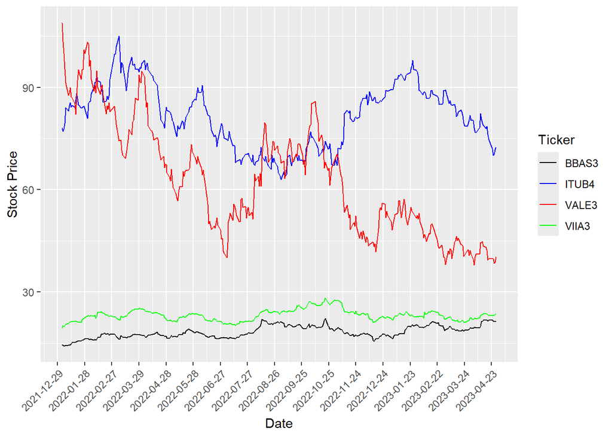

```r
#Reorganizando os dados para o formato longo usando a função pivot_longer do dplyr
dados_combinados_long <- pivot_longer(dados_combinados, -DATAS, names_to = "Ticker", values_to = "preco")
cores <- c("black", "blue", "red", "green")
ggplot(dados_combinados_long, aes(x = DATAS, y = preco, color = Ticker)) +
  geom_line() +
  labs(x = "Date", y = "Stock Price") +
  scale_x_date(date_labels = "%Y-%m-%d", date_breaks = "30 day") +
  scale_color_manual(values = cores) +
  theme(axis.text.x = element_text(angle = 45, hjust = 1))
```

```r
# Plotagem usando ggplot2
# ggplot(dados_combinados_long, aes(x = DATAS, y = preco, color = Ticker)) +
#   geom_line() +
#   labs(x = "Date", y = "Stock Price") +
#   scale_x_date(date_labels = "%Y-%m-%d", date_breaks = "30 day") +
#   theme(axis.text.x = element_text(angle = 45, hjust = 1))
```

Neste trabalho montamos nossa contribuição considerando que os retornos financeiros são independentes, para retirar a dependencia haja visto que é uma serie temporal nos trabalhamos com os incrementos, ou seja, filtramos o fechamentos dos preços diários e tomamos a diferença dos preços do dia posterior e anterior. Em processos similares como movimento browniano temos evidencias axiomática que este procedimento faz com que garantimos a independencia dos dados, para alem disso aplicamos o logaritmos nos retornos e partir de agora vamos nos referir a serie como log retornos de fechamento de preços. este procedimento de trabalhar com os incrementos e logaritmizar esta descrito nas funções abaixo.

```r
#DADOS<-read.csv(file.choose())
#BB=DADOS$bbas3 %>% as.vector()
BB=BBAS3$BBAS3.SA.Close %>% as.vector()
x_div=BB[-1]/BB[-length(BB)] #INCREMENTO
LOGBB=log(x_div)


IT=ITAU$ITUB4.SA.Close %>% as.vector()
IT_div=IT[-1]/IT[-length(IT)]
LOGIT=log(IT_div)


VL=VALE$VALE3.SA.Close  %>% as.vector()
VL_div=VL[-1]/VL[-length(VL)]
LOGVL=log(VL_div)

VIA=VIA3$BHIA3.SA.Close  %>% as.vector()
VIA_div=VIA[-1]/VIA[-length(VIA)]
LOGVIA=log(VIA_div)
```

Logo após realizamos a análise boxplot para verificar se há outliers ou não nos dados, o código abaixo nos fornece os boxplot.

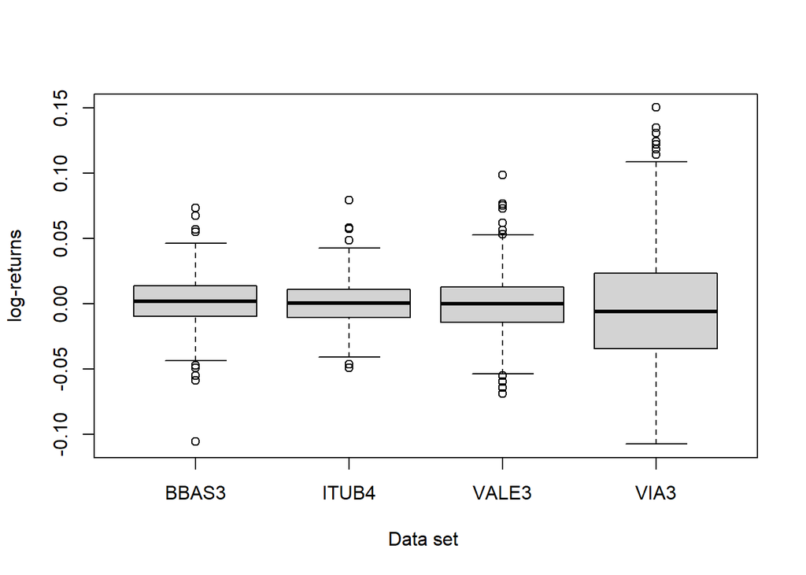

```r
lista_de_dados <- list(LOGBB, LOGIT, LOGVL, LOGVIA)
nomes_dos_datasets <- c("BBAS3", "ITUB4", "VALE3", "VIA3")

boxplot(lista_de_dados,
        names = nomes_dos_datasets,
        xlab = "Data set ",
        ylab = "log-returns",
        main = " ")
```

Para verificar se há presença de autocorrelação plotamos um gráfico ACF

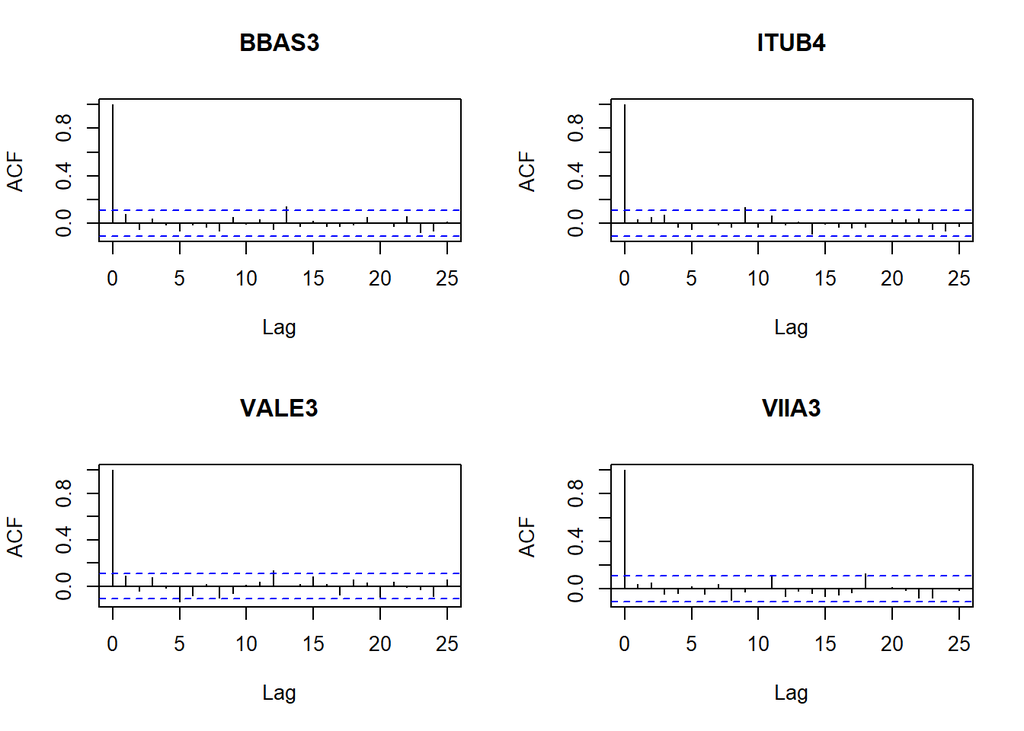

```r
BBAS3=LOGBB;ITUB4=LOGIT;VALE3=LOGVL ;VIIA3=LOGVIA
par(mfrow=c(2,2))
acf(BBAS3, main="BBAS3")
acf(ITUB4, main="ITUB4")
acf(VALE3, main="VALE3")
acf(VIIA3, main="VIIA3")
```

GRÁFICO DE AUTOCORRELAÇÃO

Nota-se que que não ha evidencia de autocorrelação nas quatro bases. Logo abaixo montamos a tabela com as principais medidas descritivas.

```r
bases=data.frame(LOGBB,LOGIT,LOGVL,LOGVIA)
descritiva= summary(bases) %>% print()
```

```
##      LOGBB               LOGIT                LOGVL
##  Min.   :-0.105659   Min.   :-0.0492130   Min.   :-0.0689439
##  1st Qu.:-0.009684   1st Qu.:-0.0104991   1st Qu.:-0.0140316
##  Median : 0.001940   Median : 0.0003995   Median : 0.0001094
##  Mean   : 0.001203   Mean   : 0.0005651   Mean   :-0.0002258
##  3rd Qu.: 0.013631   3rd Qu.: 0.0109299   3rd Qu.: 0.0128365
##  Max.   : 0.073551   Max.   : 0.0794472   Max.   : 0.0989011
##      LOGVIA
##  Min.   :-0.107542
##  1st Qu.:-0.034388
##  Median :-0.005851
##  Mean   :-0.003017
##  3rd Qu.: 0.023058
##  Max.   : 0.150404
```

Como neste trabalho consideramos que $X,Y$ ~ $GEV (\mu, \sigma, \gamma)$, ou seja seguem distribuição GEv, logo apresentaremos como se comporta esta distribuição através dos gráficos da distribuição.

[figure not shown]

```r
mu=0
sigma=0.1
k=-0.3
x=LOGBB
#devd(x, loc = 0, scale = 0.1, shape =-0.3 )
#fit_LOGBB
x_points = seq(-2,6, by=0.1)

################# variando locação ###################
par(mfrow=c(2,2))

curve(devd(x,0,0.5,-0.3),from=-2, to=6, main=TeX("$sigma=0.1, gamma=-0.3$"),
      ylab = "g(x)" ,type="b", pch=15)


lines(x_points, devd(x_points, 1,0.5,-0.3), type="b",
      pch=16,
      lty=2,
      #lwd=2.0,
      col="red")
lines(x_points, devd(x_points, -1,0.5,-0.3), type="b",
      pch=17,
      lty=2,
      #lwd=2.0,
      col="blue")
legend("topright", #inset=.05,
       y=0.5,
       title=TeX("$mu$"), c("0","1",  "-1"),
       lty=c(2), pch=15:17, col=c("black",  "red", "blue" ))


###########################varianda scala##############################################

curve(devd(x,0,0.1,-0.3),from=-2, to=6,main=TeX("$mu=0, gamma=-0.3$"),
      ylab = "g(x)" ,type="b", pch=15)


lines(x_points, devd(x_points, 0,0.5,-0.3), type="b",
      pch=16,
      lty=2,
      #lwd=2.0,
      col="red")
lines(x_points, devd(x_points, 0,1,-0.3), type="b",
      pch=17,
      lty=2,
      #lwd=2.0,
      col="blue")
legend("topright", #inset=.05,
       y=0.5,
       title=TeX("$sigma$"), c("0.1","0.5",  "1"),
       lty=c(2), pch=15:17, col=c("black",  "red", "blue" ))


#########################Variando shape###################################################
curve(devd(x,0,0.5,-1),from=-2, to=6,main=TeX("$mu=0, sigma=0.5$"),
      ylab = "g(x)" ,type="b", pch=15)

lines(x_points, devd(x_points, 0,0.5,-0.3), type="b",
      pch=17,
      lty=2,
      #lwd=2.0,
      col="blue")

lines(x_points, devd(x_points, 0,0.5,-.5), type="b",
      pch=16,
      lty=2,
      #lwd=2.0,
      col="red")

legend("topright", #inset=.05,
       y=0.5,
       title=TeX("$gamma$"), c("-1","-0.5",  "-0.3"),
       lty=c(2), pch=15:17, col=c("black",  "red", "blue" ))

#################### VARIANDO SHAPE COM SINAIS TROCADOS #############

curve(devd(x,0,1,-1),from=-2, to=6,main=TeX("$mu=0, sigma=1$"),
      ylab = "g(x)" ,type="b", pch=15)

lines(x_points, devd(x_points, 0,1,0), type="b",
      pch=17,
      lty=2,
      #lwd=2.0,
      col="blue")

lines(x_points, devd(x_points, 0,1,1), type="b",
      pch=16,
      lty=2,
      #lwd=2.0,
      col="red")

legend("topright", #inset=.05,
       y=0.5,
       title=TeX("$gamma$"), c("-1","0",  "1"),
       lty=c(2), pch=15:17, col=c("black",  "red", "blue" ))
```

Note o que cada parâmetro faz nesta distribuição, no primeiro gráfico, o parametro de escala e o de forma estão fixo variamos o parâmetros de localização perceba que ele trasmuta ou para direita o para esquerda a forma da distribuição, ja no segundo gráfico a variamos a escala e os outros ficaram fixos, perceba que esse parâmetro trabalha com a disperção dos dados, e os dois ultimos gráficos colocamos o shape, ou seja, o parâmetro de forma livre e os outros fixos, este parâmetro é muito importante pois ele determina para onde a calda da distribuição esta acentuada e a velocidade que ela decai, ele controla se é calda leve ou pesada. Para além disso, a Gev particulariza 3 distribuição, que são elas Fréchet, Weibull e distribuição Gumbel e o parâmetro de forma que idica em qual caso particular os dados se adequam, porém o objetivo deste trabalho não é focar em casos particulares e sim na distribuição que generaliza, ou seja, nosso interesse é na distribuição GEV.

Para isto vamos estimar os parametros da distribuição gev. As funções abaixo estima marginalmente via pacote extRemes, o método de estimação é por -logverossimilhança.

```r
fit_LOGBB = fevd(LOGBB,type="GEV")
parBB1=c(fit_LOGBB$results$par%>% as.list())

fit_LOGIT = fevd(LOGIT,type="GEV")
parIT=c(fit_LOGIT$results$par%>% as.list())

(fit_LOGVL = fevd(LOGVL,type="GEV"))
```

```
##
## fevd(x = LOGVL, type = "GEV")
##
## [1] "Estimation Method used: MLE"
##
##
##  Negative Log-Likelihood Value:  -774.0895
##
##
##  Estimated parameters:
##     location        scale        shape
## -0.009497271  0.022220793 -0.163093276
##
##  Standard Error Estimates:
##     location        scale        shape
## 0.0013139580 0.0008637121 0.0205215189
##
##  Estimated parameter covariance matrix.
##               location         scale         shape
## location  1.726486e-06  1.203197e-07 -7.625157e-06
## scale     1.203197e-07  7.459986e-07 -7.217747e-06
## shape    -7.625157e-06 -7.217747e-06  4.211327e-04
##
##  AIC = -1542.179
##
##  BIC = -1530.782
```

```r
parVL=c(fit_LOGVL$results$par%>% as.list())

(fit_LOGVIA = fevd(LOGVIA,type="GEV"))
```

```
##
## fevd(x = LOGVIA, type = "GEV")
##
## [1] "Estimation Method used: MLE"
##
##
##  Negative Log-Likelihood Value:  -567.698
##
##
##  Estimated parameters:
##    location       scale       shape
## -0.02165616  0.03961411 -0.11696265
##
##  Standard Error Estimates:
##    location       scale       shape
## 0.002410209 0.001673711 0.034016012
##
##  Estimated parameter covariance matrix.
##               location         scale         shape
## location  5.809106e-06  8.927438e-07 -2.828261e-05
## scale     8.927438e-07  2.801309e-06 -2.159493e-05
## shape    -2.828261e-05 -2.159493e-05  1.157089e-03
##
##  AIC = -1129.396
##
##  BIC = -1117.999
```

```r
parVIA=c(fit_LOGVIA$results$par%>% as.list())
parametros = data.frame(
  Bases = c("", "BBAS3", "ITUB4", "VALE3", "VIA3"),
  Location = c("location", parBB1$location, parIT$location, parVL$location, parVIA$location),
  Scale = c("scale", parBB1$scale, parIT$scale, parVL$scale, parVIA$scale),
  Shape = c("shape", parBB1$shape, parIT$shape, parVL$shape, parVIA$shape)
)

# Visualização do data frame
print(parametros)
```

```
##   Bases             Location              Scale              Shape
## 1                   location              scale              shape
## 2 BBAS3 -0.00631083023245223 0.0218504153182118  -0.25353884918813
## 3 ITUB4 -0.00644815639881802 0.0165100203950001 -0.154486908720825
## 4 VALE3 -0.00949727092637728 0.0222207927921888 -0.163093275576926
## 5  VIA3  -0.0216561591952117 0.0396141074349253 -0.116962645348691
```

Com os parametros estimados vamos demostrar algumas funções para continuar a análise, utilizaremos, as funções tais como distribuição acumulada GEV, Densidade GEV, função H e função para calcular o parâmetro de confiabilidade a Fit_R.

```r
H<-function(a1, a2, a3, a4, a5){
  integrand <- function(y){exp(-a1*y-(a2*y^a3+a4)^(a5))}
  integralv<-integrate(integrand, 0, Inf)$value
  return (integralv) #essa seria a integral original calculada numericamente, para comparações
}

# GEV CDF function
gev_cdf <- function(x,  mu, sigma, k) {
  if (k == 0) {
    p <- exp(-exp(-(x - mu) / sigma))
  } else {
    p <- exp(-(1 + k * (x - mu) / sigma)^(-1 / k))
  }
  return(p)
}


## Função para Estimar o R
fit_R=function(x_fit, y_fit){
  m1=y_fit[1]
  s1=y_fit[2]
  g1=y_fit[3]

  m2=x_fit[1]
  s2=x_fit[2]
  g2=x_fit[3]



  ## condicao ta atendida?

  if(g1 > 0 && g2 > 0){
    R_est=ifelse(m1-(s1/g1)>=m2-(s2/g2),
                 H(1, (g2*s1)/(s2*g1), -g1, 1+(g2/s2)*(m1-m2-(s1/g1)),   -1/g2 ),
                 1- H(1, (g1*s2)/(s1*g2), -g2, 1+(g1/s1)*(m2-m1-(s2/g2)),   -1/g1 ))
  }
  if(g1 < 0 && g2 < 0){
    R_est=ifelse(m1-(s1/g1)<=m2-(s2/g2),
                 H(1, (g2*s1)/(s2*g1), -g1, 1+(g2/s2)*(m1-m2-(s1/g1)),   -1/g2 ),
                 1- H(1, (g1*s2)/(s1*g2), -g2, 1+(g1/s1)*(m2-m1-(s2/g2)),   -1/g1 ))
    #H(1, (g1*s2)/(s1*g2), -g2, 1+(g1/s1)*(m2-m1-(s2/g2)),   -1/g1 ))

  }
  return(R_est)
}

R_hat <- function(x, y) {
  sum(x < y) / length(x)
}
```

Realizamos também um teste de Kolmogorov-smirnov para verificar se os dados se adequam a distribuição GEV. os códigos para o teste ks está definido abaixo.

```r
### Colocar os parametros estimados##########################
ks.test(LOGBB, gev_cdf,mu=parBB1$location,sigma=parBB1$scale, k=parBB1$shape)
```

```
##
##  Asymptotic one-sample Kolmogorov-Smirnov test
##
## data:  LOGBB
## D = 0.086294, p-value = 0.01467
## alternative hypothesis: two-sided
```

```r
ks.test(LOGIT, gev_cdf,mu=parIT$location,sigma=parIT$scale, k=parIT$shape)
```

```
##
##  Asymptotic one-sample Kolmogorov-Smirnov test
##
## data:  LOGIT
## D = 0.0481, p-value = 0.4299
## alternative hypothesis: two-sided
```

```r
ks.test(LOGVL, gev_cdf,mu=parVL$location ,sigma=parVL$scale, k=parVL$shape)
```

```
##
##  Asymptotic one-sample Kolmogorov-Smirnov test
##
## data:  LOGVL
## D = 0.057048, p-value = 0.2331
## alternative hypothesis: two-sided
```

```r
ks.test(LOGVIA, gev_cdf,mu=parVIA$location,sigma=parVIA$scale , k=parVIA$shape)
```

```
##
##  Asymptotic one-sample Kolmogorov-Smirnov test
##
## data:  LOGVIA
## D = 0.038916, p-value = 0.6997
## alternative hypothesis: two-sided
```

A $5\%$ de confiança apenas a BBAS3 não foi significativa porém plotamos alguns gráficos de como ficou o ajuste da distribuição aos dados e podemos perceber que o ajustou bem graficamente por este motivo decidimos manter a BBAS3 no trabalho. abaixo o gráfico dos ajuste.

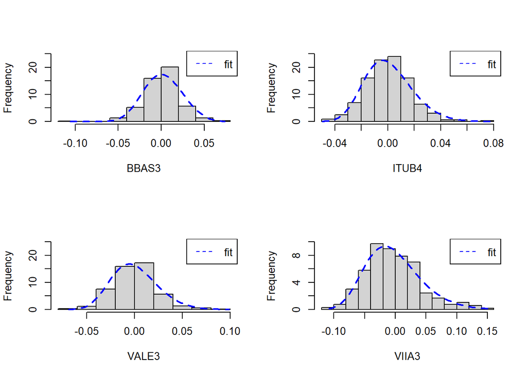

```r
par(mfrow=c(2,2))    # set the plotting area into a 1*2 array

hist(LOGBB, freq = FALSE,
     probability = TRUE,
     main = "",
     breaks = 8,
     #col = "blue", border = "white",
     xlab = "BBAS3", ylab = "Frequency",
     ylim =c(0,25)
)

x_points=seq(min(LOGBB),max(LOGBB),abs(min(LOGBB)-max(LOGBB))/100)
x_gev_points=devd(x_points, loc = parBB1$location, scale =parBB1$scale, shape = parBB1$shape)

lines(x_points, x_gev_points, type="l",
      # pch=15,
      lty=2,
      lwd=2.0,
      col="blue")

legend("topright", #inset=.05,
       y=0.5,
       #title="",
       c("fit"),
       lty=c(2),
       #pch=15,
       col=c("blue"))
##########################################
hist(LOGIT, freq = FALSE,
     probability = TRUE,
     main = "",
     breaks = 10,
     #col = "blue", border = "white",
     xlab = "ITUB4", ylab = "Frequency",
     ylim =c(0,25)
)

x_points=seq(min(LOGIT),max(LOGIT),abs(min(LOGIT)-max(LOGIT))/100)
x_gev_points=devd(x_points, loc = parIT$location, scale =parIT$scale , shape = parIT$shape)

lines(x_points, x_gev_points, type="l",
      # pch=15,
      lty=2,
      lwd=2.0,
      col="blue")

legend("topright", #inset=.05,
       y=0.5,
       #title="",
       c("fit"),
       lty=c(2),
       #pch=15,
       col=c("blue"))

##########################################
hist(LOGVL, freq = FALSE,
     probability = TRUE,
     main = "",
     breaks = 8,
     #col = "blue", border = "white",
     xlab = "VALE3", ylab = "Frequency",
     ylim =c(0,25)
)

x_points=seq(min(LOGVL),max(LOGVL),abs(min(LOGVL)-max(LOGVL))/100)
x_gev_points=devd(x_points, loc = parVL$location, scale =parVL$scale, shape = parVL$shape)

lines(x_points, x_gev_points, type="l",
      # pch=15,
      lty=2,
      lwd=2.0,
      col="blue")

legend("topright", #inset=.05,
       y=0.5,
       #title="",
       c("fit"),
       lty=c(2),
       #pch=15,
       col=c("blue"))


##########################################
hist(LOGVIA, freq = FALSE,
     probability = TRUE,
     main = "",
     breaks = 15,
     #col = "blue", border = "white",
     xlab = "VIIA3", ylab = "Frequency",
     ylim =c(0,10)
)

x_points=seq(min(LOGVIA),max(LOGVIA),abs(min(LOGVIA)-max(LOGVIA))/100)
x_gev_points=devd(x_points, loc = parVIA$location, scale =parVIA$scale , shape = parVIA$shape)

lines(x_points, x_gev_points, type="l",
      # pch=15,
      lty=2,
      lwd=2.0,
      col="blue")

legend("topright", #inset=.05,
       y=0.5,
       #title="",
       c("fit"),
       lty=c(2),
       #pch=15,
       col=c("blue"))
```

Note no grafíco acima o modelo GEV ajustou bem aos dados por isso decidimos avançar com as 4 bases.

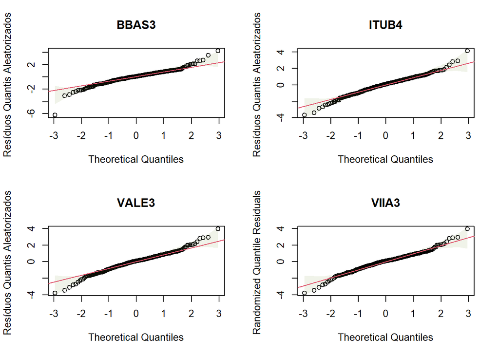

```r
######################### GRAFICO QQPLOT #############################
par(mfrow = c(2,2))
mu1 = parBB1$location; sigma1=parBB1$scale;k1=parBB1$shape
residuo1=qnorm(gev_cdf(LOGBB, mu = mu1, sigma=sigma1,k=k1))
qqenvelope(residuo1, ylab = "Resíduos Quantis Aleatorizados ", main = "BBAS3"); qqline(residuo1, col = 2)
#qqenvelope(residuo1);qqline(residuo1)

mu2 = parIT$location; sigma2=parIT$scale;k2=parIT$shape
residuo2=qnorm(gev_cdf(LOGIT, mu = mu2, sigma=sigma2,k=k2))
qqenvelope(residuo2, ylab = "Resíduos Quantis Aleatorizados ", main = "ITUB4"); qqline(residuo2, col = 2)


mu3 = parVL$location; sigma3=parVL$scale;k3=parVL$shape
residuo3=qnorm(gev_cdf(LOGVL, mu = mu3, sigma=sigma3,k=k3))
qqenvelope(residuo3, ylab = "Resíduos Quantis Aleatorizados ", main = "VALE3"); qqline(residuo3, col = 2)

mu4 = parVIA$location; sigma4=parVIA$scale;k4=parVIA$shape
residuo4=qnorm(gev_cdf(LOGVIA, m = mu4, sigma=sigma4,k=k4))
qqenvelope(residuo3, ylab = "Randomized Quantile Residuals ", main = "VIIA3"); qqline(residuo4, col = 2)
```

O gráfico acima é o gráfico de Resíduos Quantis Aleatorizados, basicamente contrastamos o nosso resíduos para verificar se ha normalidade, este modelo não possui este pressuposto, porém é interessante olhar os comportamento dos resíduos do modelo para ver se não houve anomalias muito grande no modelo.

Para a estimativa da confiabilidade que é o foco central do nosso trabalho utilizamos as expressões analiticas para obter a estimativa de stress-strength descrita na estimação abaixo, também utilizamos um abordagem não paramétrica que consiste em avaliar a quantidade de vezes em que uma ação foi menor que a outra e dividir pelo tamanho do intervalo assim obtemos uma estimativa de stress-strength via contagem e comprimimos para o intervalo 0 a 1 para comparar com a probabilidade via estimativa. Para fins didáticos consideraremos $X1 = $ BBAS3, $X2 = $ ITUB4, $X3 = $ VALE3 e $X4 = $ VIIA3

```r
############ R não parametrico ##################################
R_hat <- function(x, y) {
  sum(x < y) / length(x)
}
x1=LOGBB; x2=LOGIT; x3=LOGVL; x4=LOGVIA
par_1=R_hat(x=x3,y=x1)
par_2=R_hat(x=x3,y=x2)
par_3=R_hat(x=x3,y=x4)

############# R parametrico ##############################
fit_R=function(x_fit, y_fit){
  m1=y_fit$location
  s1=y_fit$scale
  g1=y_fit$shape

  m2=x_fit$location
  s2=x_fit$scale
  g2=x_fit$shape



  ## condicao ta atendida?

  if(g1 > 0 && g2 > 0){
    R_est=ifelse(m1-(s1/g1)>=m2-(s2/g2),
                 H(1, (g2*s1)/(s2*g1), -g1, 1+(g2/s2)*(m1-m2-(s1/g1)),   -1/g2 ),
                 1- H(1, (g1*s2)/(s1*g2), -g2, 1+(g1/s1)*(m2-m1-(s2/g2)),   -1/g1 ))
  }
  if(g1 < 0 && g2 < 0){
    R_est=ifelse(m1-(s1/g1)<=m2-(s2/g2),
                 H(1, (g2*s1)/(s2*g1), -g1, 1+(g2/s2)*(m1-m2-(s1/g1)),   -1/g2 ),
                 1- H(1, (g1*s2)/(s1*g2), -g2, 1+(g1/s1)*(m2-m1-(s2/g2)),   -1/g1 ))
    #H(1, (g1*s2)/(s1*g2), -g2, 1+(g1/s1)*(m2-m1-(s2/g2)),   -1/g1 ))

  }
  return(R_est)
}

fitR1<-R_hat(LOGVL, LOGBB) %>% round(digits = 4)
fitR1P<-fit_R(parVL,parBB1) %>% round(digits = 4)

fitR2<-R_hat(LOGVL, LOGIT) %>% round(digits = 4)
fitR2P<-fit_R(parVL,parIT) %>% round(digits = 4)

fitR3<-R_hat(LOGVL, LOGVIA) %>% round(digits = 4)
fitR3P<-fit_R(parVL,parVIA) %>% round(digits = 4)

# Criar o data frame de confiabilidade
confiabilidade = data.frame(
  Bases = c("", "X3<X1", "X3<X2", "X3<X4"),
  RNP = c("RNP", fitR1, fitR2, fitR3),
  RP = c("RP", fitR1P, fitR2P, fitR3P)
)

confiabilidade
```

| Bases | RNP | RP |
| --- | --- | --- |
|  | RNP | RP |
| X3<X1 | 0.5242 | 0.5283 |
| X3<X2 | 0.5242 | 0.5174 |
| X3<X4 | 0.4364 | 0.4506 |